# PART 1

```python
import pandas as pd
import numpy as np
import matplotlib.pyplot as plt
import seaborn as sns
import statsmodels.api as sm
from scipy import stats
from sklearn.linear_model import LinearRegression
from sklearn import datasets, linear_model
from sklearn.metrics import mean_squared_error, r2_score
from sklearn.model_selection import train_test_split, cross_val_score

!pip install mlxtend
from mlxtend.feature_selection import SequentialFeatureSelector
```

```python
# Load the dataset
car_data = pd.read_csv('car.csv')

# View the data
print("\nFirst few rows:")
print(car_data.head())

print("\nLast few rows:")
print(car_data.tail())

# Explore data shape and information
print("\nData shape:")
print(car_data.shape)

print("\nData information:")
print(car_data.info())

# Handle missing values
print("\nMissing values per column:")
print(car_data.isnull().sum())

summary_stats = car_data.describe(include='all').transpose()
print(summary_stats)
```

```
First few rows:
    MPG  Cylinders  Displacement Horsepower  Weight  Acceleration  Model Year  \
0  18.0          8         307.0        130    3504          12.0          70
1  15.0          8         350.0        165    3693          11.5          70
2  18.0          8         318.0        150    3436          11.0          70
3  16.0          8         304.0        150    3433          12.0          70
4  17.0          8         302.0        140    3449          10.5          70

   US Made
0        1
1        1
2        1
3        1
4        1

Last few rows:
      MPG  Cylinders  Displacement Horsepower  Weight  Acceleration  \
393  27.0          4         140.0         86    2790          15.6
394  44.0          4          97.0         52    2130          24.6
395  32.0          4         135.0         84    2295          11.6
396  28.0          4         120.0         79    2625          18.6
397  31.0          4         119.0         82    2720          19.4

     Model Year  US Made
393          82        1
394          82        0
395          82        1
396          82        1
397          82        1

Data shape:
(398, 8)

Data information:
<class 'pandas.core.frame.DataFrame'>
RangeIndex: 398 entries, 0 to 397
Data columns (total 8 columns):
 #   Column        Non-Null Count  Dtype
---  ------        --------------  -----
 0   MPG           398 non-null    float64
```

[output cut: 25 more lines]

```
Horsepower      398     94  150   22          NaN         NaN     NaN
Weight        398.0    NaN  NaN  NaN  2970.424623  846.841774  1613.0
Acceleration  398.0    NaN  NaN  NaN     15.56809    2.757689     8.0
Model Year    398.0    NaN  NaN  NaN     76.01005    3.697627    70.0
US Made       398.0    NaN  NaN  NaN     0.625628    0.484569     0.0

                  25%     50%     75%     max
MPG              17.5    23.0    29.0    46.6
Cylinders         4.0     4.0     8.0     8.0
Displacement   104.25   148.5   262.0   455.0
Horsepower        NaN     NaN     NaN     NaN
Weight        2223.75  2803.5  3608.0  5140.0
Acceleration   13.825    15.5  17.175    24.8
Model Year       73.0    76.0    79.0    82.0
US Made           0.0     1.0     1.0     1.0
```

We can see that horse is a numeric feature but the data type appears as an object which indicates it has some non-numeric values

```python
unique_values = car_data.Horsepower.unique()
print(unique_values)
```

```
['130' '165' '150' '140' '198' '220' '215' '225' '190' '170' '160' '95'
 '97' '85' '88' '46' '87' '90' '113' '200' '210' '193' '?' '100' '105'
 '175' '153' '180' '110' '72' '86' '70' '76' '65' '69' '60' '80' '54'
 '208' '155' '112' '92' '145' '137' '158' '167' '94' '107' '230' '49' '75'
 '91' '122' '67' '83' '78' '52' '61' '93' '148' '129' '96' '71' '98' '115'
 '53' '81' '79' '120' '152' '102' '108' '68' '58' '149' '89' '63' '48'
 '66' '139' '103' '125' '133' '138' '135' '142' '77' '62' '132' '84' '64'
 '74' '116' '82']
```

We can see that one of the unique value in horsepower is Unknown "?"

```python
if '?' in unique_values:
        wrong_data_count = car_data[car_data['Horsepower'] == '?'].shape[0]
        print(f"\nNumber of unknown values in '{'Horsepower'}' column: {wrong_data_count}")

        sample_wrong_data = car_data[car_data['Horsepower'] == '?'].sample(5)
        print(f"\nSample rows with wrong value in '{'Horsepower'}' column:")
        print(sample_wrong_data)
```

```
Number of unknown values in 'Horsepower' column: 6

Sample rows with wrong value in 'Horsepower' column:
      MPG  Cylinders  Displacement Horsepower  Weight  Acceleration  \
374  23.0          4         151.0          ?    3035          20.5
32   25.0          4          98.0          ?    2046          19.0
336  23.6          4         140.0          ?    2905          14.3
126  21.0          6         200.0          ?    2875          17.0
330  40.9          4          85.0          ?    1835          17.3

     Model Year  US Made
374          82        1
32           71        1
336          80        1
126          74        1
330          80        0
```

```python
# Convert "?" values in Horsepower column to NaN
car_data['Horsepower'] = car_data['Horsepower'].replace('?', np.nan)

# Convert Horsepower column to numeric type
car_data['Horsepower'] = car_data['Horsepower'].astype(float)
```

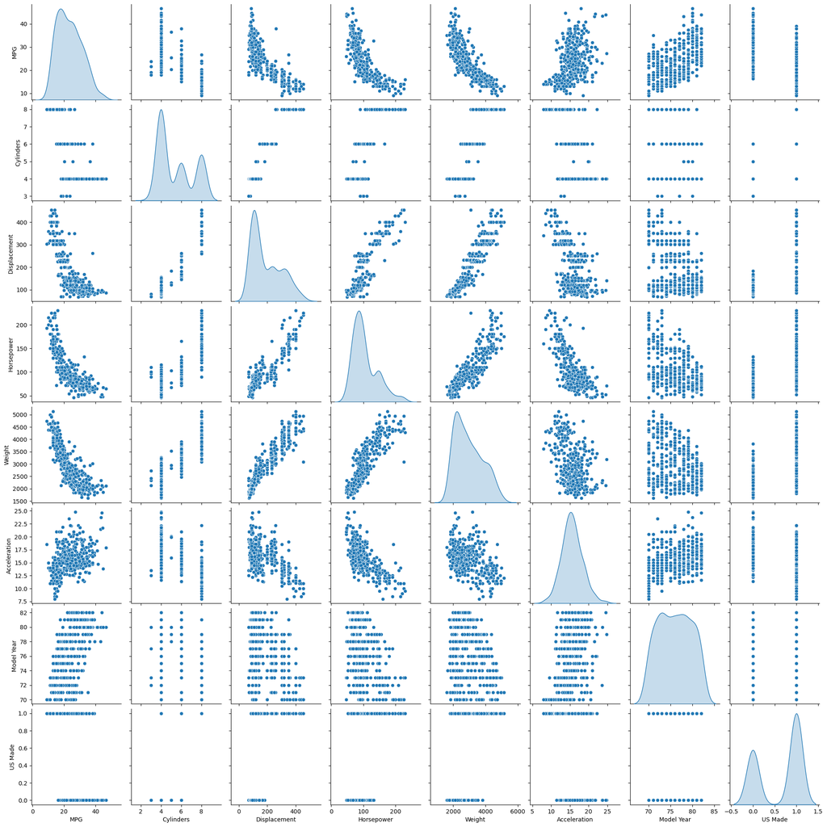

```python
sns.pairplot(car_data, diag_kind = "kde");
```

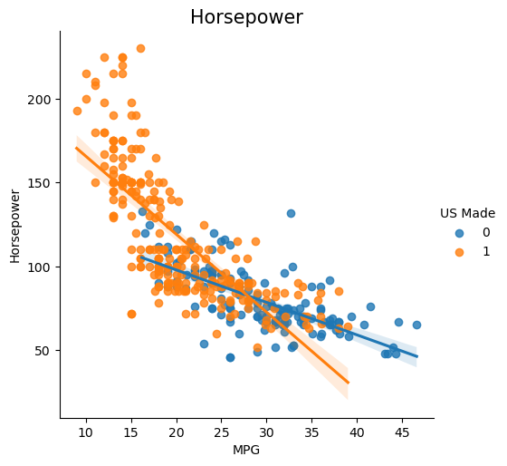

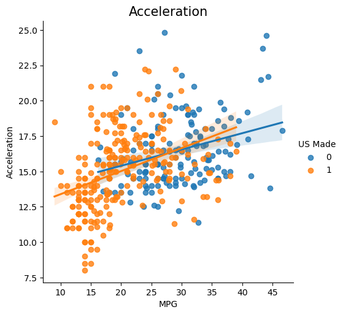

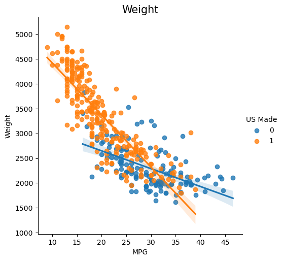

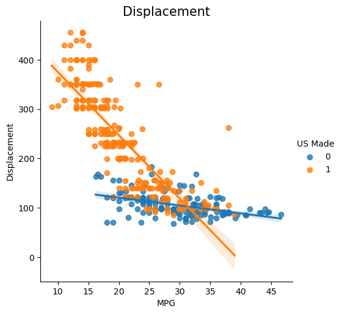

```python
for i in ["Horsepower","Acceleration","Weight","Displacement"]:
    plot = sns.lmplot(x = "MPG", y = i, data = car_data, hue = 'US Made')
    plt.title(i, fontsize = 15)
    plt.show()
```

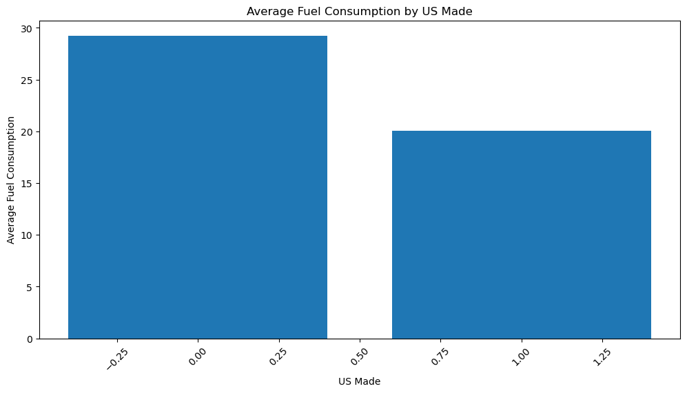

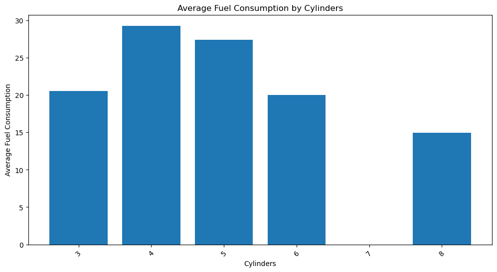

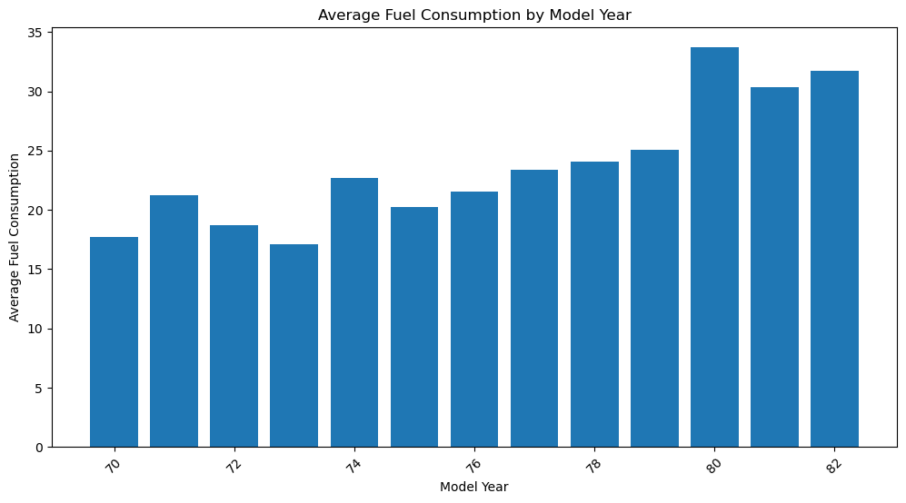

```python
for i in ["US Made", "Cylinders", "Model Year"]:
    cat_mpg = car_data.groupby(i)["MPG"].mean()

    plt.figure(figsize=(12, 6))
    plt.bar(cat_mpg.index, cat_mpg)
    plt.xlabel(i)
    plt.ylabel("Average Fuel Consumption")
    plt.title(f"Average Fuel Consumption by {i}")
    plt.xticks(rotation=45)
    plt.show()
```

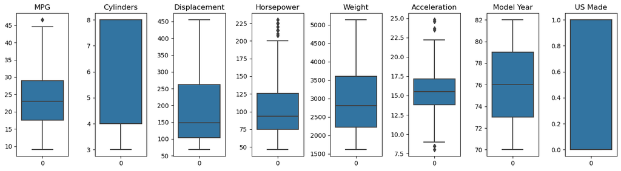

```python
x = 0
plt.figure(figsize=(16, 4))
for i in car_data.select_dtypes("number"):
    x += 1
    plt.subplot(1, 9, x)
    sns.boxplot(data=car_data[i])
    plt.title(i)

plt.tight_layout()
plt.show()
```

# Prediciting Horsepower Values

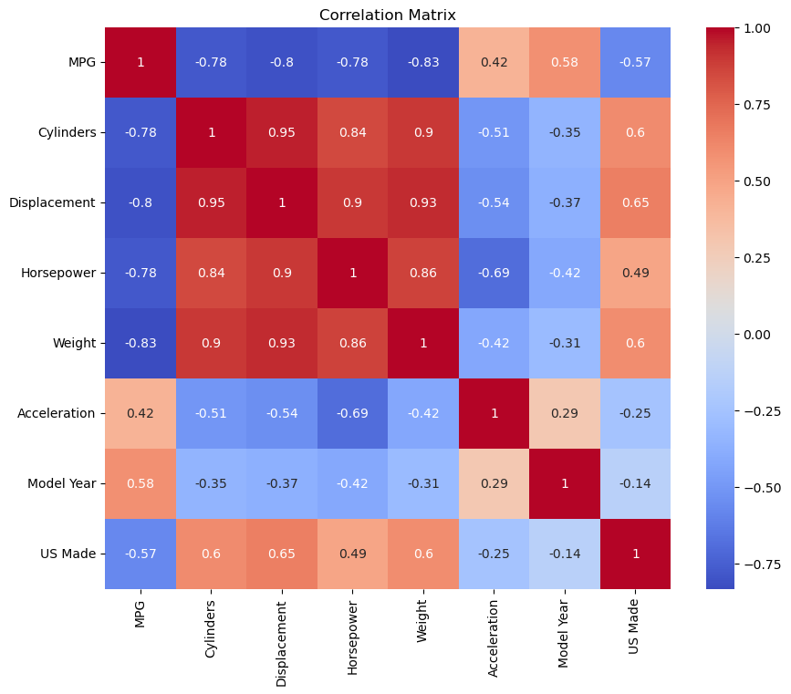

```
MPG            -0.778427
Cylinders       0.842983
Displacement    0.897257
Weight          0.864538
Acceleration   -0.689196
Model Year     -0.416361
US Made         0.489625
Name: Horsepower, dtype: float64
```

```python
correlation_matrix = car_data.corr()

plt.figure(figsize=(10, 8))
sns.heatmap(correlation_matrix, annot=True, cmap='coolwarm')
plt.title("Correlation Matrix")
plt.show()

# Print correlation matrix
HP_correlation = correlation_matrix['Horsepower'].drop('Horsepower')
print(HP_correlation)
```

We can see that Mileage is connected to Horsepower as Higher HP seems to decline mileage. To add to this reason We can Also see that more HP requires more Amount of Cylinders which can affect the overall load on the engine Thus, consuming more fuelWe can see that Acceleration & MPG is affected by Horsepower & Weight. As lighter weight vehicles produce higher acceleration with less power which can help in better Average MPG.We can see that Displacement & Weight are related to Horsepower as HP requiring more Cylinders seems to Increase Displacement Voluame resulting in Extra Weight of the Vehicle.

```python
##MODEL 1
# Separate rows with "?" values into a test set
test_set = car_data[car_data['Horsepower'].isnull()].copy()
train_set = car_data.dropna()

# Select the features and target variable
features = ['Cylinders', 'Displacement', 'Weight', 'Acceleration', 'Model Year', 'MPG', 'US Made']
target = 'Horsepower'

# Train the OLS regression model
X = train_set[features]
y = train_set[target]
X = sm.add_constant(X)  # add constant term for intercept
model = sm.OLS(y, X)
results = model.fit()

# Combine the test set with the original DataFrame
car_data_updated = pd.concat([train_set, test_set], ignore_index=True)

# Print the complete OLS regression results table
print(results.summary())

# Predict the missing values on the test set
if len(test_set) > 0:
    test_set_X = test_set[features]
    test_set_X = sm.add_constant(test_set_X)  # add constant term for intercept
    test_set['Horsepower'] = results.predict(test_set_X)

    # Print the updated values
    updated_values = test_set[['Cylinders', 'Displacement', 'Weight', 'Acceleration', 'Model Year', 'Horsepower']]
    print("Updated values:")
    print(updated_values)
```

```
                            OLS Regression Results
==============================================================================
Dep. Variable:             Horsepower   R-squared:                       0.899
Model:                            OLS   Adj. R-squared:                  0.897
Method:                 Least Squares   F-statistic:                     490.1
Date:                Sun, 04 Jun 2023   Prob (F-statistic):          4.33e-187
Time:                        23:33:13   Log-Likelihood:                -1536.7
No. Observations:                 392   AIC:                             3089.
Df Residuals:                     384   BIC:                             3121.
Df Model:                           7
Covariance Type:            nonrobust
================================================================================
                   coef    std err          t      P>|t|      [0.025      0.975]
--------------------------------------------------------------------------------
const          151.5501     15.533      9.756      0.000     121.009     182.091
Cylinders       -2.8891      1.190     -2.428      0.016      -5.229      -0.549
Displacement     0.1723      0.027      6.268      0.000       0.118       0.226
Weight           0.0189      0.003      7.412      0.000       0.014       0.024
Acceleration    -4.4168      0.289    -15.292      0.000      -4.985      -3.849
Model Year      -0.5435      0.239     -2.271      0.024      -1.014      -0.073
MPG             -0.2470      0.190     -1.300      0.194      -0.620       0.127
US Made         -8.5232      1.822     -4.678      0.000     -12.105      -4.941
==============================================================================
Omnibus:                       94.040   Durbin-Watson:                   1.353
Prob(Omnibus):                  0.000   Jarque-Bera (JB):              296.812
Skew:                           1.078   Prob(JB):                     3.53e-65
Kurtosis:                       6.677   Cond. No.                     7.75e+04
==============================================================================

Notes:
[1] Standard Errors assume that the covariance matrix of the errors is correctly specified.
[2] The condition number is large, 7.75e+04. This might indicate that there are
strong multicollinearity or other numerical problems.
Updated values:
     Cylinders  Displacement  Weight  Acceleration  Model Year  Horsepower
32           4          98.0    2046          19.0          71   58.348594
126          6         200.0    2875          17.0          74   94.009130
330          4          85.0    1835          17.3          80   59.333375
336          4         140.0    2905          14.3          80   98.035549
354          4         100.0    2320          15.8          81   78.747501
374          4         151.0    3035          20.5          82   74.065708
```

# Checking For Multicollinearity

```python
from statsmodels.stats.outliers_influence import variance_inflation_factor

# Calculate VIF for each independent variable
X = car_data_updated[['Displacement', 'Weight', 'Cylinders', 'MPG', 'Acceleration','Model Year']]
vif = pd.DataFrame()
vif['Features'] = X.columns
vif['VIF'] = [variance_inflation_factor(X.values, i) for i in range(X.shape[1])]
print(vif)
```

```
       Features         VIF
0  Displacement   83.077877
1        Weight  152.520806
2     Cylinders  115.549805
3           MPG   51.043122
4  Acceleration   49.528010
5    Model Year  248.498910
```

```python
X = car_data_updated[['Displacement', 'MPG', 'US Made']]
vif = pd.DataFrame()
vif['Features'] = X.columns
vif['VIF'] = [variance_inflation_factor(X.values, i) for i in range(X.shape[1])]
print(vif)
```

```
       Features       VIF
0  Displacement  5.587820
1           MPG  2.050303
2       US Made  4.630228
```

We can see that there is multicollinearity in variables therefore we will remove the features giving high multicollinearity resulting in feature drop

```python
##MODEL 2
# Select the features and target variable
features = ['Displacement',  'US Made' ]
target = 'Horsepower'

# Train the OLS regression model
X = train_set[features]
y = train_set[target]
X = sm.add_constant(X)  # add constant term for intercept
model = sm.OLS(y, X)
results = model.fit()

# Combine the test set with the original DataFrame
car_data_updated = pd.concat([train_set, test_set], ignore_index=True)

# Print the complete OLS regression results table
print(results.summary())

# Predict the missing values on the test set
if len(test_set) > 0:
    test_set_X = test_set[features]
    test_set_X = sm.add_constant(test_set_X)  # add constant term for intercept
    test_set['Horsepower'] = results.predict(test_set_X)

    # Print the updated values
    updated_values = test_set[['Cylinders', 'Displacement', 'Weight', 'Acceleration', 'Model Year', 'Horsepower']]
    print("Updated values:")
    print(updated_values)
```

```
                            OLS Regression Results
==============================================================================
Dep. Variable:             Horsepower   R-squared:                       0.822
Model:                            OLS   Adj. R-squared:                  0.821
Method:                 Least Squares   F-statistic:                     899.7
Date:                Sun, 04 Jun 2023   Prob (F-statistic):          1.23e-146
Time:                        23:33:13   Log-Likelihood:                -1648.1
No. Observations:                 392   AIC:                             3302.
Df Residuals:                     389   BIC:                             3314.
Df Model:                           2
Covariance Type:            nonrobust
================================================================================
                   coef    std err          t      P>|t|      [0.025      0.975]
--------------------------------------------------------------------------------
const           40.7787      1.737     23.473      0.000      37.363      44.194
Displacement     0.3719      0.010     35.704      0.000       0.351       0.392
US Made        -13.7862      2.249     -6.131      0.000     -18.207      -9.365
==============================================================================
Omnibus:                       24.215   Durbin-Watson:                   1.294
Prob(Omnibus):                  0.000   Jarque-Bera (JB):               49.023
Skew:                           0.343   Prob(JB):                     2.26e-11
Kurtosis:                       4.591   Cond. No.                         605.
==============================================================================

Notes:
[1] Standard Errors assume that the covariance matrix of the errors is correctly specified.
Updated values:
     Cylinders  Displacement  Weight  Acceleration  Model Year  Horsepower
32           4          98.0    2046          19.0          71   63.441377
126          6         200.0    2875          17.0          74  101.377905
330          4          85.0    1835          17.3          80   72.392498
336          4         140.0    2905          14.3          80   79.062300
354          4         100.0    2320          15.8          81   77.971399
374          4         151.0    3035          20.5          82   83.153494
```

# PART 3- Predictive Modeling For MPG

```python
car_data = car_data_updated

# View the data
print("\nFirst few rows:")
print(car_data.head())

# Explore data shape and information
print("\nData shape:")
print(car_data.shape)

print("\nData information:")
print(car_data.info())

# Handle missing values
print("\nMissing values per column:")
print(car_data.isnull().sum())
```

```
First few rows:
    MPG  Cylinders  Displacement  Horsepower  Weight  Acceleration  \
0  18.0          8         307.0       130.0    3504          12.0
1  15.0          8         350.0       165.0    3693          11.5
2  18.0          8         318.0       150.0    3436          11.0
3  16.0          8         304.0       150.0    3433          12.0
4  17.0          8         302.0       140.0    3449          10.5

   Model Year  US Made
0          70        1
1          70        1
2          70        1
3          70        1
4          70        1

Data shape:
(398, 8)

Data information:
<class 'pandas.core.frame.DataFrame'>
RangeIndex: 398 entries, 0 to 397
Data columns (total 8 columns):
 #   Column        Non-Null Count  Dtype
---  ------        --------------  -----
 0   MPG           398 non-null    float64
 1   Cylinders     398 non-null    int64
 2   Displacement  398 non-null    float64
 3   Horsepower    398 non-null    float64
 4   Weight        398 non-null    int64
 5   Acceleration  398 non-null    float64
 6   Model Year    398 non-null    int64
 7   US Made       398 non-null    int64
dtypes: float64(4), int64(4)
memory usage: 25.0 KB
None

Missing values per column:
MPG             0
Cylinders       0
Displacement    0
Horsepower      0
Weight          0
Acceleration    0
Model Year      0
US Made         0
dtype: int64
```

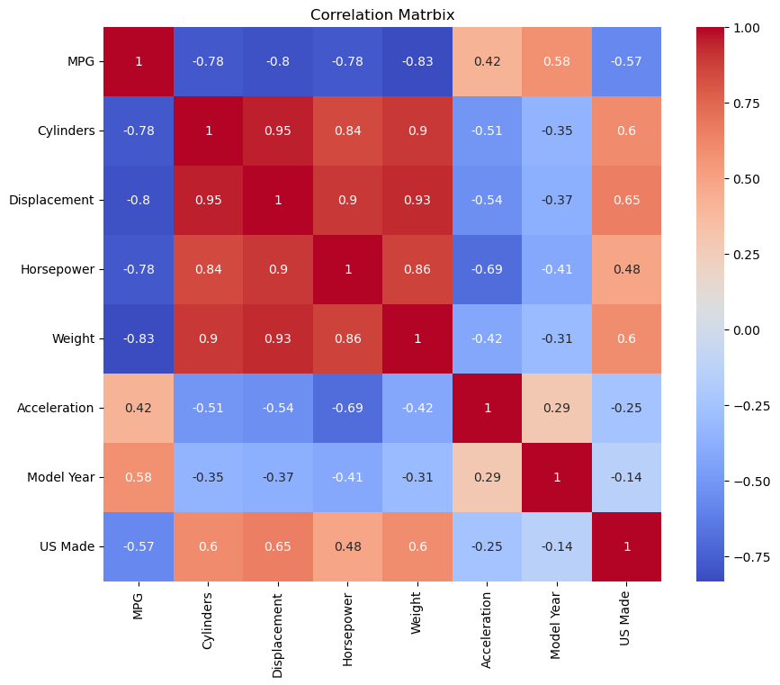

```
Cylinders      -0.775396
Displacement   -0.804203
Horsepower     -0.776769
Weight         -0.831741
Acceleration    0.420289
Model Year      0.579267
US Made        -0.568192
Name: MPG, dtype: float64
```

```python
# Plot correlation matrix

correlation_matrix = car_data_updated.corr()

plt.figure(figsize=(10, 8))
sns.heatmap(correlation_matrix, annot=True, cmap='coolwarm')
plt.title("Correlation Matrbix")
plt.show()

# Print correlation matrix with 'Salary'
HP_correlation = correlation_matrix['MPG'].drop('MPG')
print(HP_correlation)
```

```python
##MODEL 1

# Step 1: Define the features (X) and the target variable (y)
X = car_data_updated[['Cylinders', 'Displacement', 'Horsepower', 'Weight', 'Acceleration', 'Model Year', 'US Made']]
y = car_data_updated['MPG']

# Split the dataset into train and test sets
X_train, X_test, y_train, y_test = train_test_split(X, y, test_size=0.2, random_state=42)

# Add constant to X
X_train = sm.add_constant(X_train)

# Create and train the linear regression model
model = sm.OLS(y_train, X_train)
results = model.fit()

# Print the model summary
print(results.summary())

# Add constant to X_test
X_test = sm.add_constant(X_test)

# Evaluate the model on the test set
y_pred = results.predict(X_test)

# Calculate evaluation metrics
from sklearn.metrics import mean_squared_error, r2_score

mse = mean_squared_error(y_test, y_pred)
r2 = r2_score(y_test, y_pred)

print("Mean Squared Error:", mse)
print("R-squared:", r2)
```

```
                            OLS Regression Results
==============================================================================
Dep. Variable:                    MPG   R-squared:                       0.821
Model:                            OLS   Adj. R-squared:                  0.817
Method:                 Least Squares   F-statistic:                     202.7
Date:                Sun, 04 Jun 2023   Prob (F-statistic):          1.14e-111
Time:                        23:33:13   Log-Likelihood:                -833.75
No. Observations:                 318   AIC:                             1683.
Df Residuals:                     310   BIC:                             1714.
Df Model:                           7
Covariance Type:            nonrobust
================================================================================
                   coef    std err          t      P>|t|      [0.025      0.975]
--------------------------------------------------------------------------------
const          -18.0100      5.338     -3.374      0.001     -28.513      -7.507
Cylinders       -0.1233      0.367     -0.336      0.737      -0.845       0.599
Displacement     0.0191      0.009      2.201      0.028       0.002       0.036
Horsepower      -0.0178      0.016     -1.132      0.258      -0.049       0.013
Weight          -0.0068      0.001     -9.501      0.000      -0.008      -0.005
Acceleration     0.1190      0.111      1.074      0.283      -0.099       0.337
Model Year       0.7952      0.060     13.278      0.000       0.677       0.913
US Made         -2.9796      0.544     -5.472      0.000      -4.051      -1.908
==============================================================================
Omnibus:                       17.437   Durbin-Watson:                   2.065
Prob(Omnibus):                  0.000   Jarque-Bera (JB):               22.651
Skew:                           0.442   Prob(JB):                     1.21e-05
Kurtosis:                       3.963   Cond. No.                     8.76e+04
==============================================================================

Notes:
[1] Standard Errors assume that the covariance matrix of the errors is correctly specified.
[2] The condition number is large, 8.76e+04. This might indicate that there are
strong multicollinearity or other numerical problems.
Mean Squared Error: 9.30699416760901
R-squared: 0.8374636415435973
```

```python
# Forward Stepwise Selection
lr_model = LinearRegression()
sfs = SequentialFeatureSelector(lr_model,
                                k_features=2,
                                forward=True,
                                floating=False,
                                verbose=3,
                                scoring='r2')

# Perform forward feature selection
sf1 = sfs.fit(X_train, y_train)


# Get the selected feature indices
selected_feature_indices = sf1.k_feature_idx_

# Get the selected feature names
selected_feature_names = X_train.columns[list(selected_feature_indices)]

# Print the selected features
print("Selected Features:")
for feature in selected_feature_names:
    print("- ", feature)
```

```
Selected Features:
-  Weight
-  Model Year
```

[output not shown]

```python
##BACKWARD SELECTION
# Define the SequentialFeatureSelector
sfs = SequentialFeatureSelector(lr_model,
                                k_features=2,
                                forward=False,
                                floating=False,
                                verbose=3,
                                scoring='r2')

# Perform forward feature selection
sf1 = sfs.fit(X_train, y_train)


# Get the selected feature indices
selected_feature_indices = sf1.k_feature_idx_

# Get the selected feature names
selected_feature_names = X_train.columns[list(selected_feature_indices)]

# Print the selected features
print("Selected Features:")
for feature in selected_feature_names:
    print("- ", feature)
```

[output not shown]

```
Selected Features:
-  Weight
-  Model Year
```

[output not shown]

```
                            OLS Regression Results
==============================================================================
Dep. Variable:                    MPG   R-squared:                       0.802
Model:                            OLS   Adj. R-squared:                  0.801
Method:                 Least Squares   F-statistic:                     637.8
Date:                Sun, 04 Jun 2023   Prob (F-statistic):          1.74e-111
Time:                        23:44:40   Log-Likelihood:                -849.56
No. Observations:                 318   AIC:                             1705.
Df Residuals:                     315   BIC:                             1716.
Df Model:                           2
Covariance Type:            nonrobust
==============================================================================
                 coef    std err          t      P>|t|      [0.025      0.975]
------------------------------------------------------------------------------
const        -15.7998      4.629     -3.413      0.001     -24.907      -6.692
Weight        -0.0067      0.000    -27.223      0.000      -0.007      -0.006
Model Year     0.7782      0.057     13.624      0.000       0.666       0.891
==============================================================================
Omnibus:                       37.253   Durbin-Watson:                   2.098
Prob(Omnibus):                  0.000   Jarque-Bera (JB):               59.746
Skew:                           0.718   Prob(JB):                     1.06e-13
Kurtosis:                       4.565   Cond. No.                     7.26e+04
==============================================================================

Notes:
[1] Standard Errors assume that the covariance matrix of the errors is correctly specified.
[2] The condition number is large, 7.26e+04. This might indicate that there are
strong multicollinearity or other numerical problems.
R-squared: 0.8323029835393867
Mean Squared Error: 9.602498597524589
```

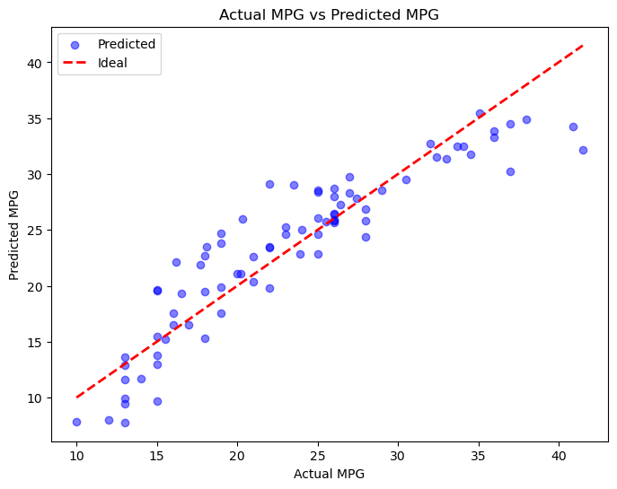

```python
##MODEL 2
# Define the features
X = car_data_updated[['Weight','Model Year']]

# Add constant to X
X = sm.add_constant(X)

# Define the target variable
y = car_data_updated['MPG']

# Split the data into train and test sets
X_train, X_test, y_train, y_test = train_test_split(X, y, test_size=0.2, random_state=42)

# Create and train the linear regression model
model = sm.OLS(y_train, X_train)
results = model.fit()

# Print the model summary
print(results.summary())

# Calculate evaluation metrics

# Evaluate the model on the test set
y_pred = results.predict(X_test)

# Calculate R-squared
r2 = r2_score(y_test, y_pred)

# Calculate mean squared error
mse = mean_squared_error(y_test, y_pred)

# Print R-squared and MSE
print("R-squared:", r2)
print("Mean Squared Error:", mse)

# Visualize the predicted vs actual values
plt.figure(figsize=(8, 6))
plt.scatter(y_test, y_pred, c='blue', alpha=0.5, label='Predicted')
plt.plot([min(y_test), max(y_test)], [min(y_test), max(y_test)], color='red', linestyle='--', linewidth=2, label='Ideal')
plt.xlabel('Actual MPG')
plt.ylabel('Predicted MPG')
plt.title('Actual MPG vs Predicted MPG')
plt.legend()
plt.show()
```